# Assignment_7_MVA

2024-03-24

Answers are computed in the below code

```r
# Factor Analysis

library(psych)
#for loading csv data
library(readr)
# Read the CSV file
df <- read_csv("C:/Rutgers/Subjects/Spring Sem/Multivariate Analysis/Data/wine_new.csv")
#dataframe
df
```

```
## # A tibble: 1,143 × 12
##    `fixed acidity` `volatile acidity` `citric acid` `residual sugar` chlorides
##              <dbl>              <dbl>         <dbl>            <dbl>     <dbl>
##  1             7.4               0.7           0                 1.9     0.076
##  2             7.8               0.88          0                 2.6     0.098
##  3             7.8               0.76          0.04              2.3     0.092
##  4            11.2               0.28          0.56              1.9     0.075
##  5             7.4               0.7           0                 1.9     0.076
##  6             7.4               0.66          0                 1.8     0.075
##  7             7.9               0.6           0.06              1.6     0.069
##  8             7.3               0.65          0                 1.2     0.065
##  9             7.8               0.58          0.02              2       0.073
## 10             6.7               0.58          0.08              1.8     0.097
## # ℹ 1,133 more rows
## # ℹ 7 more variables: `free sulfur dioxide` <dbl>,
## #   `total sulfur dioxide` <dbl>, density <dbl>, pH <dbl>, sulphates <dbl>,
## #   alcohol <dbl>, quality <chr>
```

```r
# Assuming df is your dataframe
attach(df)

#selected these columns because of positive and negative correlation, other columns were not beneficial for analysis
selected_cols <- df


selected_cols
```

```
## # A tibble: 1,143 × 12
##    `fixed acidity` `volatile acidity` `citric acid` `residual sugar` chlorides
##              <dbl>              <dbl>         <dbl>            <dbl>     <dbl>
##  1             7.4               0.7           0                 1.9     0.076
##  2             7.8               0.88          0                 2.6     0.098
##  3             7.8               0.76          0.04              2.3     0.092
##  4            11.2               0.28          0.56              1.9     0.075
##  5             7.4               0.7           0                 1.9     0.076
##  6             7.4               0.66          0                 1.8     0.075
##  7             7.9               0.6           0.06              1.6     0.069
##  8             7.3               0.65          0                 1.2     0.065
##  9             7.8               0.58          0.02              2       0.073
## 10             6.7               0.58          0.08              1.8     0.097
## # ℹ 1,133 more rows
## # ℹ 7 more variables: `free sulfur dioxide` <dbl>,
## #   `total sulfur dioxide` <dbl>, density <dbl>, pH <dbl>, sulphates <dbl>,
## #   alcohol <dbl>, quality <chr>
```

Data Pre-processing:

Group by to calculate mean for all the attributes per target variable value.

```r
# Group by column 6 and calculate the average of all other columns within each group
grouped_avg <- aggregate(. ~ quality, data = selected_cols[, -4], FUN = mean)

# Print the grouped averages
print(grouped_avg)
```

```
##     quality fixed acidity volatile acidity citric acid  chlorides
## 1   Average      8.161077        0.5852795   0.2401242 0.09177019
## 2       Bad      8.450000        0.8975000   0.2116667 0.10533333
## 3 Excellent      8.806250        0.4100000   0.4325000 0.07018750
## 4      Good      8.317749        0.5049567   0.2636797 0.08528139
## 5      Poor      7.809091        0.7000000   0.1657576 0.09478788
## 6 Very Good      8.851049        0.3936713   0.3865734 0.07521678
##   free sulfur dioxide total sulfur dioxide   density       pH sulphates
## 1           16.612836             55.29917 0.9970727 3.302091 0.6133747
## 2            8.166667             24.50000 0.9976817 3.361667 0.5500000
## 3           11.062500             29.37500 0.9955531 3.240625 0.7662500
## 4           15.215368             39.94156 0.9966095 3.323788 0.6765368
## 5           14.848485             40.60606 0.9966694 3.391212 0.6378788
## 6           14.538462             37.48951 0.9960708 3.287133 0.7435664
##     alcohol
## 1  9.902277
## 2  9.691667
## 3 11.937500
## 4 10.655339
## 5 10.260606
## 6 11.482634
```

```r
# Set the first column as row names
row.names(grouped_avg) <- grouped_avg[, 1]  # Assuming the first column contains row names

# Remove the first column from the dataframe
grouped_avg <- grouped_avg[, -1]

# View the dataframe
grouped_avg
```

```
##           fixed acidity volatile acidity citric acid  chlorides
## Average        8.161077        0.5852795   0.2401242 0.09177019
## Bad            8.450000        0.8975000   0.2116667 0.10533333
## Excellent      8.806250        0.4100000   0.4325000 0.07018750
## Good           8.317749        0.5049567   0.2636797 0.08528139
## Poor           7.809091        0.7000000   0.1657576 0.09478788
## Very Good      8.851049        0.3936713   0.3865734 0.07521678
##           free sulfur dioxide total sulfur dioxide   density       pH sulphates
## Average             16.612836             55.29917 0.9970727 3.302091 0.6133747
## Bad                  8.166667             24.50000 0.9976817 3.361667 0.5500000
## Excellent           11.062500             29.37500 0.9955531 3.240625 0.7662500
## Good                15.215368             39.94156 0.9966095 3.323788 0.6765368
## Poor                14.848485             40.60606 0.9966694 3.391212 0.6378788
## Very Good           14.538462             37.48951 0.9960708 3.287133 0.7435664
##             alcohol
## Average    9.902277
## Bad        9.691667
## Excellent 11.937500
## Good      10.655339
## Poor      10.260606
## Very Good 11.482634
```

2. Explain the output for your factor model

principal(): This function from the psych package in R is used to perform PCA.

nfactors=3: This parameter specifies the number of factors or components to be extracted from the data. In this case, it’s set to 3, indicating that the analysis will produce three principal components.

rotate=“varimax”: This parameter specifies the rotation method to be applied to the extracted components. “Varimax” is a common rotation method used in PCA to simplify the interpretation of the components by maximizing the variance of the squared loadings within each component.

[1] Observation 1:

Overall, the PCA results suggest that the three principal components derived from the dataset adequately summarize the underlying structure of the data, with a high proportion of variance explained and a good fit of the model to the data.

RMSR of 0.01 suggests that the model’s residuals, or the differences between the observed and predicted values, are quite small, indicating a good fit of the model to the data.

[2] Observation 2:

[1] We have 3 component factors: RC1, RC2 and RC3

RC1 - has high positive correlation with: density, chlorides and Volatile acidity

RC1 - negative correlation with: alcohol and citric acid

RC2 - High positive correlation with Sulphur dioxide components

[2] “alcohol” has h2 values of 0.99 indicating that 99% of its variance is explained by principal components.

Com (Communality): These values represent the proportion of variance in each variable that is accounted for by the principal components.

It is calculated as 1 - u2.

Higher values indicate that more variance in the variable is explained by the principal components.

```r
fit.pc <- principal(grouped_avg[-1], nfactors=3, rotate="varimax")
fit.pc
```

```
## Principal Components Analysis
## Call: principal(r = grouped_avg[-1], nfactors = 3, rotate = "varimax")
## Standardized loadings (pattern matrix) based upon correlation matrix
##                        RC1   RC2   RC3   h2      u2 com
## volatile acidity      0.84 -0.35  0.39 0.98 0.01556 1.8
## citric acid          -0.74 -0.21 -0.63 0.99 0.01208 2.1
## chlorides             0.91 -0.10  0.40 1.00 0.00027 1.4
## free sulfur dioxide  -0.20  0.97  0.11 0.99 0.00528 1.1
## total sulfur dioxide  0.14  0.98 -0.07 0.99 0.01084 1.1
## density               0.97 -0.03  0.19 0.97 0.02622 1.1
## pH                    0.56 -0.01  0.82 0.99 0.00575 1.8
## sulphates            -0.97  0.05 -0.25 1.00 0.00025 1.1
## alcohol              -0.94 -0.16 -0.29 1.00 0.00055 1.2
##
##                        RC1  RC2  RC3
## SS loadings           5.23 2.11 1.58
## Proportion Var        0.58 0.23 0.18
## Cumulative Var        0.58 0.82 0.99
## Proportion Explained  0.59 0.24 0.18
## Cumulative Proportion 0.59 0.82 1.00
##
## Mean item complexity =  1.4
## Test of the hypothesis that 3 components are sufficient.
##
## The root mean square of the residuals (RMSR) is  0.01
##  with the empirical chi square  0.02  with prob <  1
##
## Fit based upon off diagonal values = 1
```

These eigenvalues represent the amount of variance explained by each principal component. The higher the eigenvalue, the more variance the corresponding principal component explains in the dataset. In this case, PC1 explains the highest amount of variance, followed by PC2, PC3, and so on.

```r
round(fit.pc$values, 3)
```

```
## [1] 6.337 2.109 0.478 0.063 0.014 0.000 0.000 0.000 0.000
```

Loadings:

Variables with higher absolute loadings (close to 1 or -1) on a particular principal component contribute more to that component’s interpretation.

Observations:

```r
fit.pc$loadings
```

```
##
## Loadings:
##                      RC1    RC2    RC3
## volatile acidity      0.842 -0.350  0.391
## citric acid          -0.742 -0.206 -0.628
## chlorides             0.911         0.401
## free sulfur dioxide  -0.196  0.971  0.114
## total sulfur dioxide  0.140  0.982
## density               0.968         0.188
## pH                    0.562         0.824
## sulphates            -0.967        -0.248
## alcohol              -0.945 -0.156 -0.287
##
##                  RC1   RC2   RC3
## SS loadings    5.230 2.110 1.583
## Proportion Var 0.581 0.234 0.176
## Cumulative Var 0.581 0.816 0.991
```

These values represent the standardized loadings of the variables on each principal component. They indicate the strength and direction of the relationship between each variable and the corresponding component.

These loadings help in understanding the contribution of each variable to each principal component. Positive loadings indicate that the variable increases as the component increases, while negative loadings indicate the opposite.

```r
# Loadings with more digits
for (i in c(1,3,2)) { print(fit.pc$loadings[[1,i]])}
```

```
## [1] 0.8419645
## [1] 0.3910259
## [1] -0.3501938
```

Observations:

Chlorides: 99.94% of the variance in chlorides is explained by the principal components.

Sulphates: 99.86% of the variance in sulphates is explained by the principal components.

Alcohol: 99.95% of the variance in alcohol is explained by the principal components.

These values indicate how well each variable is represented by the principal components. Higher communalities suggest that the variable is well captured by the principal components and contributes significantly to the underlying structure.

```r
# Communalities
fit.pc$communality
```

```
##     volatile acidity          citric acid            chlorides
##            0.9844413            0.9879237            0.9997271
##  free sulfur dioxide total sulfur dioxide              density
##            0.9947191            0.9891620            0.9737830
##                   pH            sulphates              alcohol
##            0.9942539            0.9997452            0.9994502
```

RC1:

Observation 2: This observation has the highest positive score on RC1 among all observations, indicating a strong positive association with the factors represented by RC1. This suggests that Observation 2 is strongly influenced by the characteristics or variables captured by RC1.

RC2:

RC3:

```r
# Rotated factor scores, Notice the columns ordering: RC1, RC3, RC2 and RC4
fit.pc$scores
```

```
##                 RC1        RC2         RC3
## Average    2.526558  2.7228016  0.68396598
## Bad        7.555390 -3.3661798  3.14012666
## Excellent -7.713515 -1.4680504 -3.96613312
## Good      -0.487706  0.9465044  0.01352126
## Poor       3.422658  0.6947206  2.56799571
## Very Good -5.303385  0.4702036 -2.43947649
```

1. Decide how many Factors are ideal for your dataset Ans: As per analysis 2-3 factors are best as per the elbow

Observations:

[1] 2 RCA’s see, to indicate most of the variance before the elbow point. Indicating that we should only use 2 factors ideally, as RCA’s.

[2] rest of the points are below the reference line and cover up less variance.

```r
# Play with FA utilities

fa.parallel(grouped_avg[-1]) # See factor recommendation
```

[output not shown]

[output not shown]

[output not shown]

[output not shown]

[output not shown]

[output not shown]

[output not shown]

[output not shown]

[output not shown]

[output not shown]

[output not shown]

[output not shown]

[output not shown]

[output not shown]

[output not shown]

[output not shown]

[output not shown]

[output not shown]

[output not shown]

[output not shown]

[output not shown]

[output not shown]

[output not shown]

[output not shown]

[output not shown]

[output not shown]

[output not shown]

[output not shown]

[output not shown]

[output not shown]

[output not shown]

[output not shown]

[output not shown]

[output not shown]

[output not shown]

[output not shown]

[output not shown]

[output not shown]

[output not shown]

[output not shown]

[output not shown]

[output not shown]

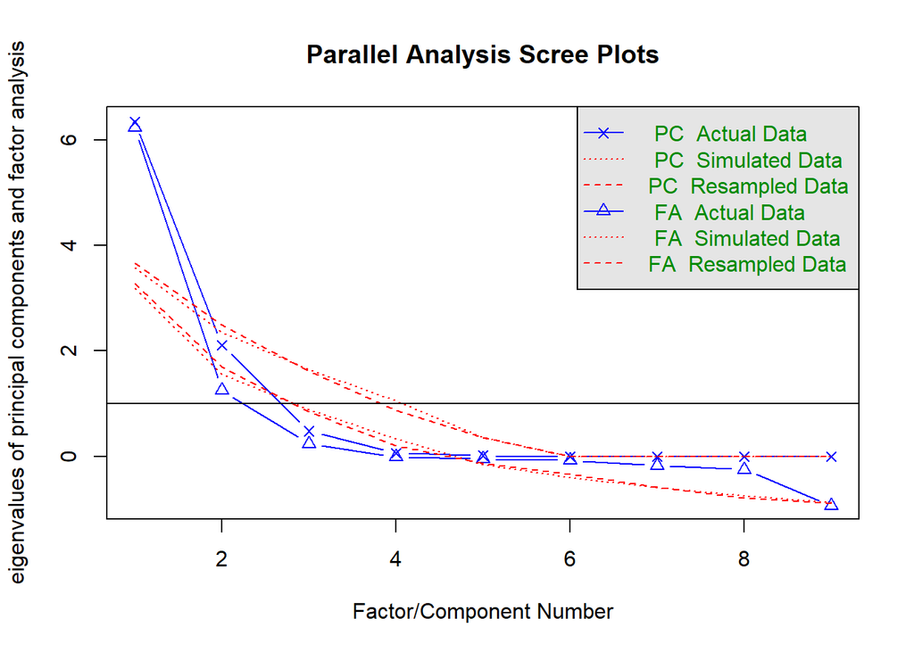

```
## Parallel analysis suggests that the number of factors =  1  and the number of components =  1
```

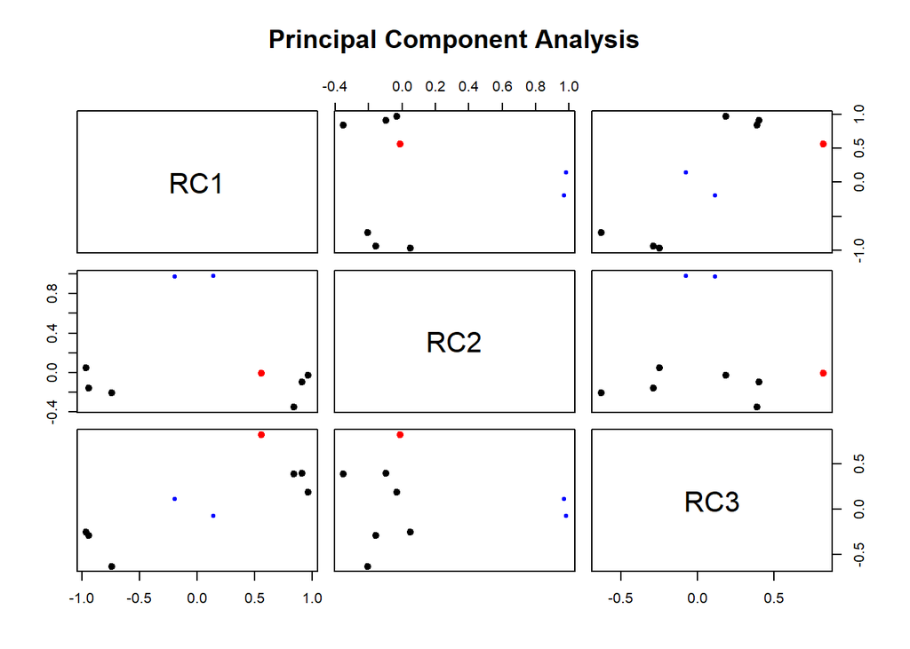

```r
fa.plot(fit.pc) # See Correlations within Factors
```

Component Analysis:

3. Show the columns that go into each factor

Correlation of variables to factors and contribution of each variable

RC1: density, chlorides and volatile acidity are positively correlated with RC1

sulphates and alcohol have high negative correlation with RC1

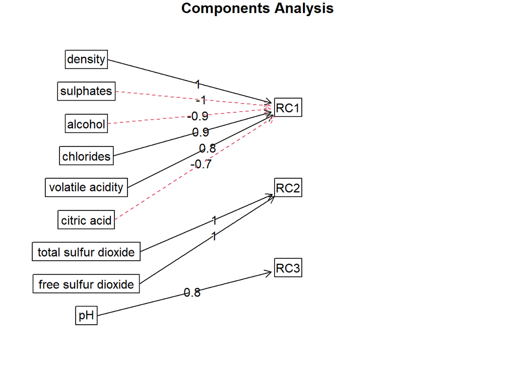

```r
fa.diagram(fit.pc) # Visualize the relationship
```

4. Perform some visualizations using the factors

[1] 2-3 factors are the points where the elbows are present

[2] 2 factors are the best as per elbow present at 2nd point after that the line is not very vertical

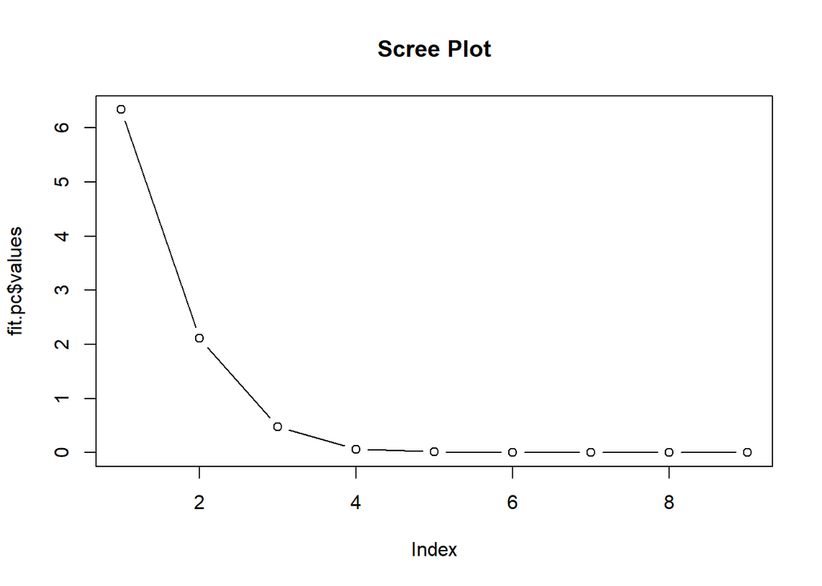

```r
plot(fit.pc$values, type="b", main="Scree Plot")
```

3. Show the columns that go into each factor

Observation:

Used bar plot to map each attribute in respective factors.

Correlation of variables to factors and contribution of each variable

RC1: density, chlorides and volatile acidity are positively correlated with RC1

sulphates and alcohol have high negative correlation with RC1

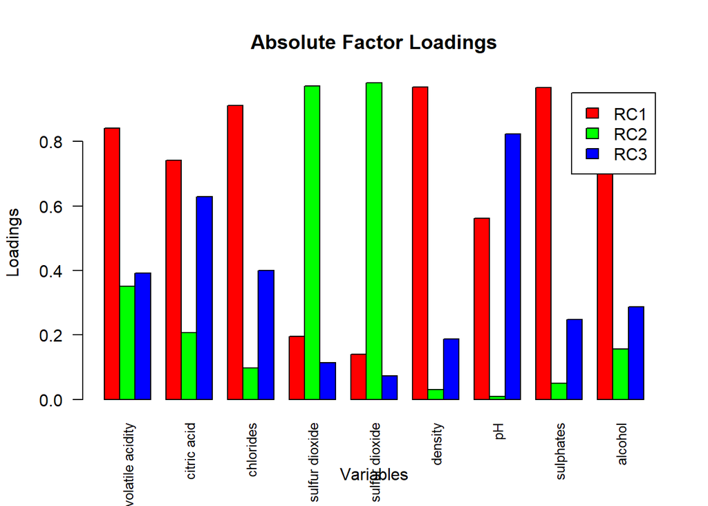

```r
# Calculate the absolute values of factor loadings
loadings_abs <- abs(fit.pc$loadings)

# Create a bar plot for factor loadings
barplot(t(loadings_abs), beside = TRUE, col = rainbow(ncol(loadings_abs)),
        main = "Absolute Factor Loadings", xlab = "Variables", ylab = "Loadings",
        legend.text = TRUE, las = 2, cex.names = 0.8)  # Rotate x-axis labels and adjust their size
```

```r
# Rotate x-axis labels to vertical position and adjust their size
```

The VSS scores suggest that a very simple structure with 2 factors achieves a high level of fit.

We get best results when factors are 2 as per Very Simple Structure Life

```r
vss(grouped_avg[-1]) # See Factor recommendations for a simple structure
```

[output not shown]

[output not shown]

[output not shown]

[output not shown]

[output not shown]

[output not shown]

[output not shown]

[output not shown]

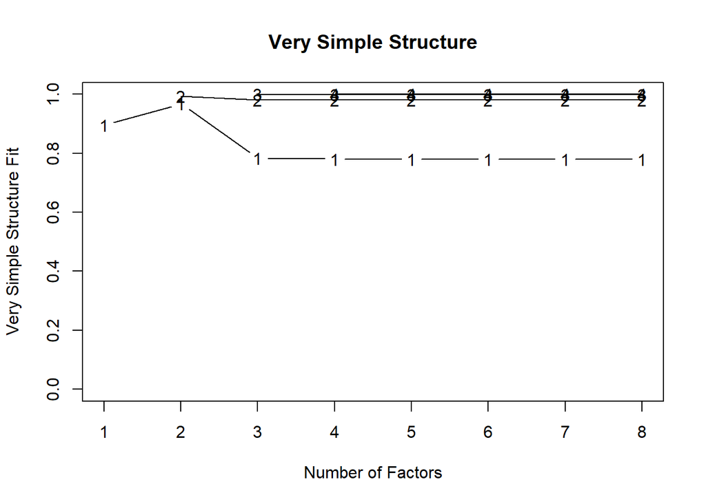

```
##
## Very Simple Structure
## Call: vss(x = grouped_avg[-1])
## VSS complexity 1 achieves a maximimum of 0.97  with  2  factors
## VSS complexity 2 achieves a maximimum of 0.99  with  2  factors
##
## The Velicer MAP achieves a minimum of 0.39  with  1  factors
## BIC achieves a minimum of  -3907563  with  2  factors
## Sample Size adjusted BIC achieves a minimum of  -3907508  with  2  factors
##
## Statistics by number of factors
##   vss1 vss2  map dof chisq  prob sqresid  fit RMSEA      BIC    SABIC complex
## 1 0.89 0.00 0.39  27    43 0.026 4.71330 0.89  0.26 -5.4e+00       73     1.0
## 2 0.97 0.99 0.57  19     0 1.000 0.26845 0.99  0.00 -3.9e+06 -3907508     1.1
## 3 0.78 0.98 0.47  12     0 1.000 0.00632 1.00  0.00 -3.1e+06 -3110836     1.4
## 4 0.78 0.98 1.00   6     0 1.000 0.00038 1.00  0.00 -1.1e+02      -90     1.4
## 5 0.78 0.98  NaN   1     0 1.000 0.00013 1.00  0.00 -1.4e+02     -135     1.4
## 6 0.78 0.98  NaN  -3     0    NA 0.00013 1.00    NA       NA       NA     1.4
## 7 0.78 0.98  NaN  -6     0    NA 0.00013 1.00    NA       NA       NA     1.4
## 8 0.78 0.98  NaN  -8     0    NA 0.00013 1.00    NA       NA       NA     1.4
##    eChisq    SRMR  eCRMS  eBIC
## 1 1.6e+01 0.19004 0.2194 -32.8
## 2 7.7e-01 0.04226 0.0582 -33.3
## 3 1.1e-02 0.00506 0.0088 -21.5
## 4 5.7e-04 0.00115 0.0028 -10.7
## 5 2.5e-04 0.00075 0.0045  -1.8
## 6 2.5e-04 0.00075     NA    NA
## 7 2.5e-04 0.00075     NA    NA
## 8 2.5e-04 0.00075     NA    NA
```

High Positive Correlations:

volatile acidity & citric acid: They exhibit a strong negative correlation of approximately -0.80, indicating that as one variable increases, the other tends to decrease, and vice versa.

chlorides & density: They show a strong positive correlation of approximately 0.96, suggesting that as one variable increases, the other also tends to increase, and vice versa.

volatile acidity & chlorides: They have a strong positive correlation of approximately 0.96, indicating a similar trend as chlorides and density.

Moderate Positive Correlations:

free sulfur dioxide & total sulfur dioxide: They demonstrate a moderate positive correlation of approximately 0.91, suggesting a moderate relationship between these two variables.

density & pH: They exhibit a moderate positive correlation of approximately 0.71, indicating a moderate positive relationship between the density and pH of the solution. Strong Negative Correlations:

sulphates & chlorides: They display a strong negative correlation of approximately -0.99, indicating that as one variable increases, the other tends to decrease, and vice versa.

sulphates & density: They show a strong negative correlation of approximately -0.98, suggesting an inverse relationship between sulphates and density.

Moderate Negative Correlations:

pH & citric acid: They have a moderate negative correlation of approximately -0.92, indicating an inverse relationship between pH and citric acid.

pH & sulphates: They exhibit a moderate negative correlation of approximately -0.75, suggesting an inverse relationship between pH and sulphates.

```r
matstd.can <- scale(grouped_avg)
matstd.can
```

```
##           fixed acidity volatile acidity citric acid  chlorides
## Average      -0.6013575       0.01758824  -0.4157915  0.3597692
## Bad           0.1282826       1.64310930  -0.6893140  1.4037560
## Excellent     1.0279477      -0.89497363   1.4332464 -1.3015000
## Good         -0.2057010      -0.40059824  -0.1893863 -0.1396888
## Poor         -1.4902536       0.61486032  -1.1305735  0.5920480
## Very Good     1.1410818      -0.97998599   0.9918188 -0.9143845
##           free sulfur dioxide total sulfur dioxide       density         pH
## Average             1.0150395           1.63738908  6.217861e-01 -0.2909003
## Bad                -1.6595289          -1.25580824  1.439465e+00  0.8156693
## Excellent          -0.7425328          -0.79786291 -1.418361e+00 -1.4325849
## Good                0.5725164           0.19473322  1.172608e-05  0.1121005
## Poor                0.4563390           0.25715489  8.036560e-02  1.3644530
## Very Good           0.3581669          -0.03560605 -7.232670e-01 -0.5687377
##            sulphates       alcohol
## Average   -0.6288205 -0.8436926707
## Bad       -1.4067659 -1.0797555321
## Excellent  1.2477728  1.4374844590
## Good       0.1465142  0.0003757336
## Poor      -0.3280254 -0.4420603952
## Very Good  0.9693247  0.9276484054
## attr(,"scaled:center")
##        fixed acidity     volatile acidity          citric acid
##           8.39920256           0.58190126           0.28338359
##            chlorides  free sulfur dioxide total sulfur dioxide
##           0.08709618          13.40738624          37.86855023
##              density                   pH            sulphates
##           0.99660954           3.31775261           0.66460113
##              alcohol
##          10.65500388
## attr(,"scaled:scale")
##        fixed acidity     volatile acidity          citric acid
##         3.959807e-01         1.920741e-01         1.040410e-01
##            chlorides  free sulfur dioxide total sulfur dioxide
##         1.299168e-02         3.157956e+00         1.064538e+01
##              density                   pH            sulphates
##         7.448114e-04         5.383807e-02         8.146425e-02
##              alcohol
##         8.921809e-01
```

Volatile Acidity and Citric Acid:

They have a strong negative correlation of approximately -0.80, suggesting that as the volatile acidity increases, the citric acid tends to decrease, and vice versa. Chlorides and Density:

They exhibit a strong positive correlation of approximately 0.96, indicating that as the concentration of chlorides increases, the density also tends to increase. Free Sulfur Dioxide and Total Sulfur Dioxide:

They show a moderate positive correlation of approximately 0.91, suggesting that the levels of free sulfur dioxide and total sulfur dioxide tend to increase together. Sulphates and Chlorides:

They display a strong negative correlation of approximately -0.99, indicating an inverse relationship between sulphates and chlorides. pH and Citric Acid:

They have a moderate negative correlation of approximately -0.92, suggesting an inverse relationship between pH and citric acid. Sulphates and Density:

They exhibit a strong negative correlation of approximately -0.98, indicating an inverse relationship between sulphates and density. Alcohol and Chlorides:

They show a strong negative correlation of approximately -0.96, suggesting that as the alcohol content increases, the concentration of chlorides tends to decrease.

```r
# Computing Correlation Matrix
corrm.emp <- cor(grouped_avg[-1])
corrm.emp
```

```
##                      volatile acidity citric acid    chlorides
## volatile acidity            1.0000000  -0.8027789  0.958746076
## citric acid                -0.8027789   1.0000000 -0.906478075
## chlorides                   0.9587461  -0.9064781  1.000000000
## free sulfur dioxide        -0.4688300  -0.1222912 -0.227057780
## total sulfur dioxide       -0.2411134  -0.2643255  0.004451211
## density                     0.8807462  -0.8183699  0.959855450
## pH                          0.7937278  -0.9244950  0.843412095
## sulphates                  -0.9299123   0.8648062 -0.985194279
## alcohol                    -0.8513089   0.9150260 -0.960026969
##                      free sulfur dioxide total sulfur dioxide     density
## volatile acidity           -0.4688300123         -0.241113429  0.88074617
## citric acid                -0.1222911510         -0.264325499 -0.81836987
## chlorides                  -0.2270577802          0.004451211  0.95985545
## free sulfur dioxide         1.0000000000          0.910917763 -0.18537720
## total sulfur dioxide        0.9109177631          1.000000000  0.07769861
## density                    -0.1853771978          0.077698613  1.00000000
## pH                         -0.0204062350          0.007064232  0.70923566
## sulphates                   0.2102299594         -0.069776628 -0.98264313
## alcohol                    -0.0002273318         -0.263807504 -0.96484059
##                                pH   sulphates       alcohol
## volatile acidity      0.793727768 -0.92991231 -0.8513088926
## citric acid          -0.924495029  0.86480622  0.9150260204
## chlorides             0.843412095 -0.98519428 -0.9600269688
## free sulfur dioxide  -0.020406235  0.21022996 -0.0002273318
## total sulfur dioxide  0.007064232 -0.06977663 -0.2638075044
## density               0.709235663 -0.98264313 -0.9648405891
## pH                    1.000000000 -0.74690293 -0.7650657404
## sulphates            -0.746902928  1.00000000  0.9774806274
## alcohol              -0.765065740  0.97748063  1.0000000000
```

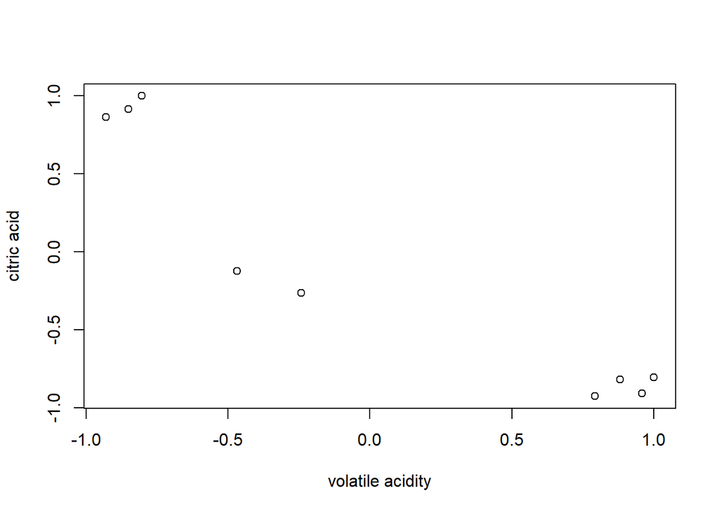

```r
plot(corrm.emp)
```

```r
grouped_avg_pca <- prcomp(grouped_avg[-1], scale=TRUE)
summary(grouped_avg_pca)
```

```
## Importance of components:
##                           PC1    PC2    PC3     PC4     PC5       PC6
## Standard deviation     2.5173 1.4521 0.6913 0.25041 0.11870 4.488e-14
## Proportion of Variance 0.7041 0.2343 0.0531 0.00697 0.00157 0.000e+00
## Cumulative Proportion  0.7041 0.9384 0.9915 0.99843 1.00000 1.000e+00
```

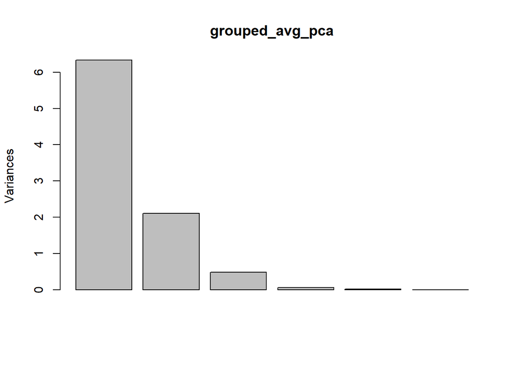

```r
plot(grouped_avg_pca)
```

The first principal component explains the highest variance with an eigenvalue of 6.337. The second principal component explains a substantial amount of variance with an eigenvalue of 2.109. The third principal component explains a moderate amount of variance with an eigenvalue of 0.478. The fourth to sixth principal components have eigenvalues of 0.063, 0.014, and 0.000 respectively, indicating diminishing contribution to the overall variance explained.

```r
# A table containing eigenvalues and %'s accounted, follows. Eigenvalues are the sdev^2
(eigen_grouped_avg <- round(grouped_avg_pca$sdev^2,3))
```

```
## [1] 6.337 2.109 0.478 0.063 0.014 0.000
```

```r
round(fit.pc$values, 3)
```

```
## [1] 6.337 2.109 0.478 0.063 0.014 0.000 0.000 0.000 0.000
```

PC1 has the highest eigenvalue of 6.337, indicating that it explains the most variance in the data.

PC2 follows with an eigenvalue of 2.109, explaining a significant amount of variance but less than PC1.

PC3 has an eigenvalue of 0.478, explaining a moderate amount of variance compared to PC1 and PC2.

PC4, PC5, and PC6 have eigenvalues of 0.063, 0.014, and 0.000 respectively, suggesting that they contribute very little to the overall variance in the data.

```r
names(eigen_grouped_avg) <- paste("PC", 1:6, sep="")
eigen_grouped_avg
```

```
##   PC1   PC2   PC3   PC4   PC5   PC6
## 6.337 2.109 0.478 0.063 0.014 0.000
```

the sum of the eigenvalues is 9.001. This value indicates the total amount of variance explained by all the principal components combined.

```r
sumlambdas <- sum(eigen_grouped_avg)
sumlambdas
```

```
## [1] 9.001
```

PC1 and PC2 are significant as per the proportion

```r
propvar <- round(eigen_grouped_avg/sumlambdas,2)
propvar
```

```
##  PC1  PC2  PC3  PC4  PC5  PC6
## 0.70 0.23 0.05 0.01 0.00 0.00
```

```r
cumvar_grouped_avg <- cumsum(propvar)
cumvar_grouped_avg
```

```
##  PC1  PC2  PC3  PC4  PC5  PC6
## 0.70 0.93 0.98 0.99 0.99 0.99
```

```r
matlambdas <- rbind(eigen_grouped_avg,propvar,cumvar_grouped_avg)
matlambdas
```

```
##                      PC1   PC2   PC3   PC4   PC5  PC6
## eigen_grouped_avg  6.337 2.109 0.478 0.063 0.014 0.00
## propvar            0.700 0.230 0.050 0.010 0.000 0.00
## cumvar_grouped_avg 0.700 0.930 0.980 0.990 0.990 0.99
```

```r
rownames(matlambdas) <- c("Eigenvalues","Prop. variance","Cum. prop. variance")
rownames(matlambdas)
```

```
## [1] "Eigenvalues"         "Prop. variance"      "Cum. prop. variance"
```

```r
eigvec.emp <- grouped_avg_pca$rotation
print(grouped_avg_pca)
```

```
## Standard deviations (1, .., p=6):
## [1] 2.517306e+00 1.452068e+00 6.912826e-01 2.504072e-01 1.187040e-01
## [6] 4.487563e-14
##
## Rotation (n x k) = (9 x 6):
##                              PC1          PC2         PC3         PC4
## volatile acidity      0.37461970  0.212337152 -0.01163319 -0.46504802
## citric acid          -0.36970340  0.181664852  0.33055908  0.28654637
## chlorides             0.39643081  0.037488131  0.04301008 -0.01338652
## free sulfur dioxide  -0.06766019 -0.671304240 -0.18018171  0.28955431
## total sulfur dioxide  0.02024154 -0.671398569  0.27486375 -0.37746680
## density               0.37923759  0.002379703  0.36135919  0.64619543
## pH                    0.34272584 -0.042923295 -0.71753985  0.23323535
## sulphates            -0.38951093 -0.012751147 -0.28194026  0.05214186
## alcohol              -0.38449128  0.130649799 -0.23621126 -0.02081815
##                              PC5         PC6
## volatile acidity      0.37654169 -0.26001688
## citric acid           0.70118273  0.35872069
## chlorides             0.13627657  0.29744865
## free sulfur dioxide  -0.04101415  0.17293565
## total sulfur dioxide  0.36758101 -0.21930675
## density               0.04900664 -0.55261333
## pH                    0.40708483  0.07325444
## sulphates             0.07734800 -0.40290034
## alcohol               0.19258100 -0.40516221
```

```r
# Taking the first four PCs to generate linear combinations for all the variables with four factors
pcafactors.grouped_avg <- eigvec.emp[,1:4]
pcafactors.grouped_avg
```

```
##                              PC1          PC2         PC3         PC4
## volatile acidity      0.37461970  0.212337152 -0.01163319 -0.46504802
## citric acid          -0.36970340  0.181664852  0.33055908  0.28654637
## chlorides             0.39643081  0.037488131  0.04301008 -0.01338652
## free sulfur dioxide  -0.06766019 -0.671304240 -0.18018171  0.28955431
## total sulfur dioxide  0.02024154 -0.671398569  0.27486375 -0.37746680
## density               0.37923759  0.002379703  0.36135919  0.64619543
## pH                    0.34272584 -0.042923295 -0.71753985  0.23323535
## sulphates            -0.38951093 -0.012751147 -0.28194026  0.05214186
## alcohol              -0.38449128  0.130649799 -0.23621126 -0.02081815
```

PC1 (Principal Component 1): It seems to be influenced strongly by variables like volatile acidity, citric acid, and density. These variables might be crucial in understanding the main patterns in the data.

PC2 (Principal Component 2): This component is primarily influenced by free sulfur dioxide and total sulfur dioxide, suggesting a relationship between these two variables.

PC3 (Principal Component 3): It appears to be influenced by variables like pH and sulphates, indicating a potential relationship between acidity and sulphates in the data.

```r
# Multiplying each column of the eigenvector’s matrix by the square-root of the corresponding eigenvalue in order to get the factor loadings
unrot.fact.grouped_avg <- sweep(pcafactors.grouped_avg,MARGIN=2,grouped_avg_pca$sdev[1:4],`*`)
unrot.fact.grouped_avg
```

```
##                              PC1          PC2          PC3          PC4
## volatile acidity      0.94303255  0.308328066 -0.008041821 -0.116451390
## citric acid          -0.93065673  0.263789789  0.228509739  0.071753284
## chlorides             0.99793781  0.054435330  0.029732116 -0.003352082
## free sulfur dioxide  -0.17032143 -0.974779667 -0.124556480  0.072506494
## total sulfur dioxide  0.05095416 -0.974916640  0.190008529 -0.094520419
## density               0.95465721  0.003455491  0.249801319  0.161812011
## pH                    0.86274595 -0.062327560 -0.496022807  0.058403819
## sulphates            -0.98051835 -0.018515538 -0.194900394  0.013056698
## alcohol              -0.96788234  0.189712444 -0.163288734 -0.005213016
```

Volatile Acidity: Almost all of the variance in volatile acidity (around 99.8%) is explained by the extracted components. This suggests that the extracted components capture the variability in volatile acidity quite well.

Citric Acid: Similarly, a high proportion (around 99.3%) of the variance in citric acid is accounted for by the extracted components, indicating a good fit of the model to this variable.

Chlorides, Free Sulfur Dioxide, Total Sulfur Dioxide, Density, pH, Sulphates, Alcohol: These variables also show high communalities, ranging from approximately 99.7% to 99.9%, implying that the extracted components explain most of the variance in these variables.

Overall, high communalities indicate that the extracted components capture a large portion of the variance in each variable, suggesting a good fit of the PCA model to the data.

```r
# Computing communalities
communalities.grouped_avg <- rowSums(unrot.fact.grouped_avg^2)
communalities.grouped_avg
```

```
##     volatile acidity          citric acid            chlorides
##            0.9980022            0.9930722            0.9997383
##  free sulfur dioxide total sulfur dioxide              density
##            0.9999763            0.9980961            0.9999662
##                   pH            sulphates              alcohol
##            0.9976649            0.9999157            0.9994774
```

```r
# Performing the varimax rotation. The default in the varimax function is norm=TRUE thus, Kaiser normalization is carried out
rot.fact.grouped_avg <- varimax(unrot.fact.grouped_avg)
#View(unrot.fact.emp)
rot.fact.grouped_avg
```

```
## $loadings
##
## Loadings:
##                      PC1    PC2    PC3    PC4
## volatile acidity      0.832  0.349 -0.397 -0.160
## citric acid          -0.734  0.207  0.633  0.101
## chlorides             0.907        -0.406
## free sulfur dioxide  -0.191 -0.970 -0.112
## total sulfur dioxide  0.138 -0.983
## density               0.974        -0.193  0.115
## pH                    0.559        -0.827
## sulphates            -0.964         0.254
## alcohol              -0.943  0.155  0.293
##
##                  PC1   PC2   PC3   PC4
## SS loadings    5.189 2.110 1.613 0.074
## Proportion Var 0.577 0.234 0.179 0.008
## Cumulative Var 0.577 0.811 0.990 0.998
##
## $rotmat
##             [,1]        [,2]         [,3]        [,4]
## [1,]  0.89675817  0.04546885 -0.438197368 -0.04171859
## [2,] -0.01331841  0.99680278  0.077515944 -0.01407529
## [3,]  0.43965454 -0.06412469  0.895512462 -0.02548219
## [4,]  0.04849017  0.01431168  0.005637002  0.99870521
```

```r
# The print method of varimax omits loadings less than abs(0.1). In order to display all the loadings, it is necessary to ask explicitly the contents of the object $loadings
fact.load.grouped_avg <- rot.fact.grouped_avg$loadings[1:9,1:4]
fact.load.grouped_avg
```

```
##                             PC1         PC2         PC3         PC4
## volatile acidity      0.8323833  0.34906994 -0.39719203 -0.15977748
## citric acid          -0.7341426  0.20700430  0.63329704  0.10095022
## chlorides             0.9070932  0.09768183 -0.40646753 -0.04650413
## free sulfur dioxide  -0.1910006 -0.97038257 -0.11205972  0.09641247
## total sulfur dioxide  0.1376327 -0.98301977  0.07172263 -0.08764337
## density               0.9737232  0.03314898 -0.19344809  0.11536142
## pH                    0.5592579  0.00974294 -0.82674977  0.03585268
## sulphates            -0.9640970 -0.05035459  0.25376318  0.05917274
## alcohol              -0.9425265  0.15549363  0.29257275  0.03666312
```

Citric Acid: “Excellent” wines tend to have the highest levels of citric acid, while “Poor” wines have the lowest. The difference between different quality categories is notable.

Chlorides: Again, “Bad” wines exhibit the highest levels of chlorides, while “Excellent” wines have the lowest. This attribute also shows considerable variation across quality categories.

Density: There’s a clear distinction between quality categories, with “Excellent” wines having significantly lower density compared to “Bad” wines, and other categories falling in between.

pH: The pH levels seem to vary across different quality categories, with “Excellent” wines showing lower pH values compared to “Bad” wines.

```r
# Computing the rotated factor scores for the 30 European Countries. Notice that signs are reversed for factors F2 (PC2), F3 (PC3) and F4 (PC4)
scale.grouped_avg <- scale(grouped_avg[-1])
scale.grouped_avg
```

```
##           volatile acidity citric acid  chlorides free sulfur dioxide
## Average         0.01758824  -0.4157915  0.3597692           1.0150395
## Bad             1.64310930  -0.6893140  1.4037560          -1.6595289
## Excellent      -0.89497363   1.4332464 -1.3015000          -0.7425328
## Good           -0.40059824  -0.1893863 -0.1396888           0.5725164
## Poor            0.61486032  -1.1305735  0.5920480           0.4563390
## Very Good      -0.97998599   0.9918188 -0.9143845           0.3581669
##           total sulfur dioxide       density         pH  sulphates
## Average             1.63738908  6.217861e-01 -0.2909003 -0.6288205
## Bad                -1.25580824  1.439465e+00  0.8156693 -1.4067659
## Excellent          -0.79786291 -1.418361e+00 -1.4325849  1.2477728
## Good                0.19473322  1.172608e-05  0.1121005  0.1465142
## Poor                0.25715489  8.036560e-02  1.3644530 -0.3280254
## Very Good          -0.03560605 -7.232670e-01 -0.5687377  0.9693247
##                 alcohol
## Average   -0.8436926707
## Bad       -1.0797555321
## Excellent  1.4374844590
## Good       0.0003757336
## Poor      -0.4420603952
## Very Good  0.9276484054
## attr(,"scaled:center")
##     volatile acidity          citric acid            chlorides
##           0.58190126           0.28338359           0.08709618
##  free sulfur dioxide total sulfur dioxide              density
##          13.40738624          37.86855023           0.99660954
##                   pH            sulphates              alcohol
##           3.31775261           0.66460113          10.65500388
## attr(,"scaled:scale")
##     volatile acidity          citric acid            chlorides
##         1.920741e-01         1.040410e-01         1.299168e-02
##  free sulfur dioxide total sulfur dioxide              density
##         3.157956e+00         1.064538e+01         7.448114e-04
##                   pH            sulphates              alcohol
##         5.383807e-02         8.146425e-02         8.921809e-01
```

PC1 (First Principal Component):

Samples categorized as “Average” have positive scores on PC3. Samples categorized as “Good” have slightly negative scores on PC3. Samples categorized as “Excellent”, “Bad”, “Poor”, and “Very Good” have varied scores on PC3, with no clear trend. PC4 (Fourth Principal Component):

Samples categorized as “Average” and “Poor” have negative scores on PC4. Samples categorized as “Good” have a positive score on PC4. Samples categorized as “Bad”, “Excellent”, and “Very Good” have varied scores on PC4, with no clear trend.

```r
as.matrix(scale.grouped_avg)%*%fact.load.grouped_avg%*%solve(t(fact.load.grouped_avg)%*%fact.load.grouped_avg)
```

```
##                  PC1        PC2          PC3        PC4
## Average    0.9449695 -1.4019118  0.961806415 -0.5813039
## Bad        1.3983516  1.4585663 -0.003680084  0.2415607
## Excellent -1.1773550  0.7891638  0.872621449 -1.0988900
## Good      -0.1607888 -0.4104615 -0.300714376  1.0548560
## Poor      -0.1602169 -0.3206390 -1.778060739 -0.8592563
## Very Good -0.8449605 -0.1147178  0.248027335  1.2430335
```